# 904971914_stats102a_hw1

Xiaoshu Luo 904971914

2020/1/14

## Question 1

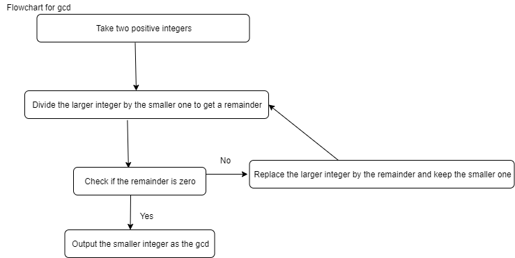

Pseudocode for GCD:

1.Take in two positive integers.

2.Repeatedly:  
Divide the larger one by the smaller one to get a remainder  
If the remainder is zero, stop  
Else:  
Replace the larger integer by the remainder and keep the smaller one

3.output the smaller integer as the greatest common divisor.

Pseudocode for GCD3:  
1. Take in three positive integers  
2. Apply gcd function to the first two to get a result  
3. Apply gcd function to the result and the third integer

```r
source("904971914_stats102a_hw1.R")
gcd(1071, 462)  # 21
```

```
## [1] 21
```

```r
gcd(462, 1071) # 21
```

```
## [1] 21
```

```r
gcd(646, 1406) # 38
```

```
## [1] 38
```

```r
gcd(1, 10) # 1
```

```
## [1] 1
```

```r
try(gcd(4.5, 12))
```

```
## Error in gcd(4.5, 12) : input has to be two positive integers!
```

```r
try(gcd(-1, 12))
```

```
## Error in gcd(-1, 12) : input has to be two positive integers!
```

```r
gcd_3(1071, 462, 4452)
```

```
## [1] 21
```

```r
gcd_3(646,1406, 4218)
```

```
## [1] 38
```

## Question 2

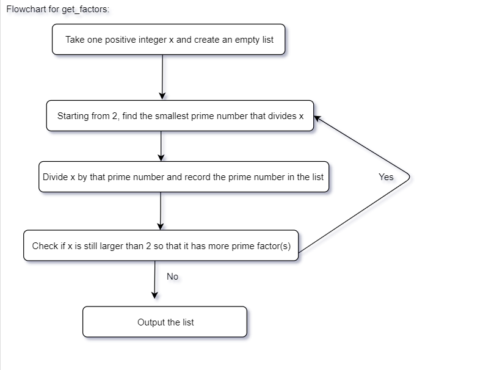

Pseudocode for get_factors:  
1. Take in a positive integer “a” and create an empty list  
2. Set i to be a test factor for a (initialized as 2)  
3. While i <= a  
If i divides a and is prime:  
Update a to be a/i  
Add i to the list  
Reset i to be 2  
Else  
Increment i by 1  
4. Output the list

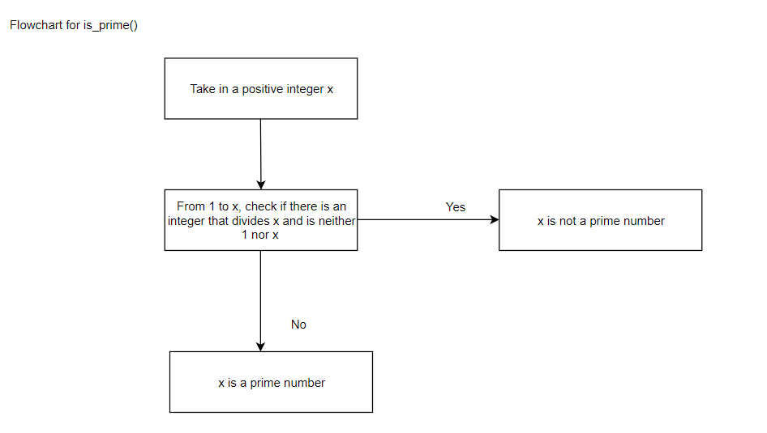

Pseudocode for is_prime:  
1. Take in a positive integer x  
2. If x >1:  
For i in 1 to x:  
If i divides x and i is neither 1 nor x  
Output False  
If no such i exists, output True  
Else if x=1:  
Return False

```r
  is_prime(9)
```

```
## [1] FALSE
```

```r
  is_prime(c(2,97,23,51,119, -1, 0,1.5)) # T,T,T,F,F,F,F,F
```

```
## [1]  TRUE  TRUE  TRUE FALSE FALSE FALSE FALSE FALSE
```

```r
  get_factors(12) # 2,2,3
```

```
## [1] 2 2 3
```

```r
  get_factors(1800) # 2,2,2,3,3,5,5
```

```
## [1] 2 2 2 3 3 5 5
```

```r
  get_factors(32851) # 7,13,19,19
```

```
## [1]  7 13 19 19
```

```r
  get_factors(9587) # 9587
```

```
## [1] 9587
```

```r
  try(get_factors(-280))  # ERROR
```

```
## Error in get_factors(-280) : input has to be a positive integer!
```

```r
  try(get_factors(280.75)) # ERROR
```

```
## Error in get_factors(280.75) : input has to be a positive integer!
```